# Movies project markdown

# 📅 Trend Over Time

## Revenue & Budget by Year:

Analyze how total budget or revenue trends have changed over the years.

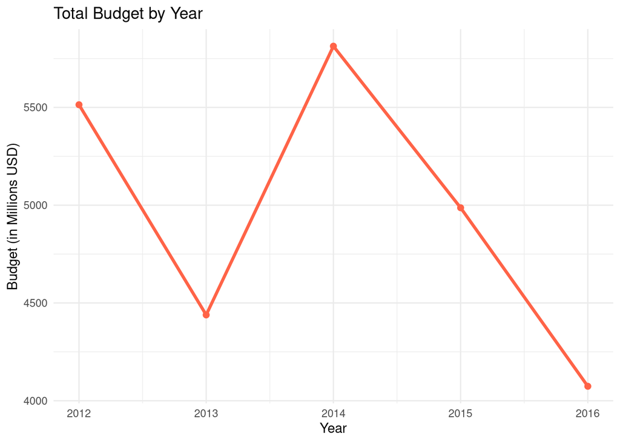

```r
# Parse date-time and extract year
yearly_data <- clean_movie_data %>%
mutate(Release_Date_Parsed = mdy_hm(`Release Date`)) %>%
mutate(Year = year(Release_Date_Parsed)) %>%
  group_by(Year) %>%
  summarise(
    Total_Budget = round(sum(Budget, na.rm = TRUE) / 1e6, 1),
    Total_Revenue = round(sum(`Box Office Revenue`,na.rm = TRUE)/1e6,1),
    Movie_count= n()
  ) %>%
  arrange(Year)

# Plot 1: Total Budget
ggplot(yearly_data, aes(x = Year, y = Total_Budget)) +
  geom_line(color = "tomato", linewidth = 1.2) +
  geom_point(color = "tomato", size = 2) +
  labs(
    title = "Total Budget by Year",
    x = "Year",
    y = "Budget (in Millions USD)"
  ) +
  theme_minimal()
```

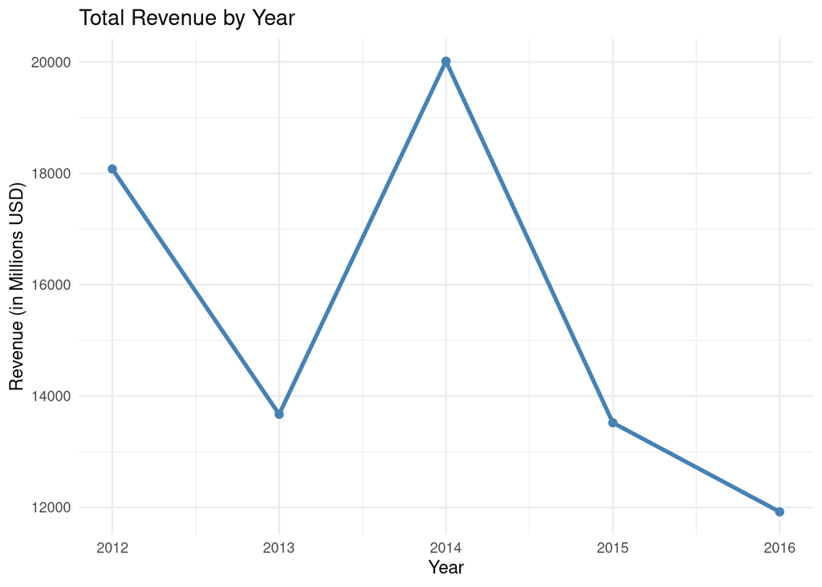

```r
# Plot 2: Total Revenue
ggplot(yearly_data, aes(x = Year, y = Total_Revenue)) +
  geom_line(color = "steelblue", linewidth = 1.2) +
  geom_point(color = "steelblue", size = 2) +
  labs(
    title = "Total Revenue by Year",
    x = "Year",
    y = "Revenue (in Millions USD)"
  ) +
  theme_minimal()
```

Number of Movies Released per Year: Detect spikes or declines in production.

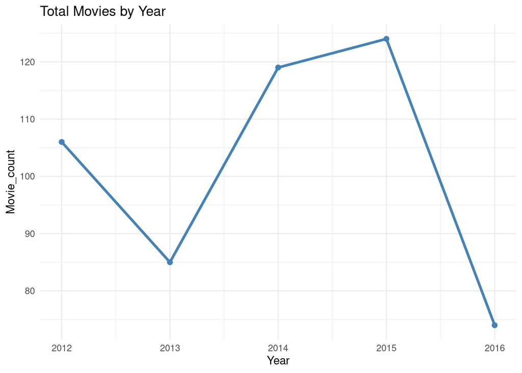

```r
## total movie count per year
ggplot(yearly_data, aes(x = Year, y = Movie_count)) +
  geom_line(color = "steelblue", linewidth = 1.2) +
  geom_point(color = "steelblue", size = 2) +
  labs(
    title = "Total Movies by Year",
    x = "Year",
    y = "Movie_count"
  ) +
  theme_minimal()
```

# ⭐ Cast Popularity and Impact

## Most Frequent Actors:

Identify top recurring actors across movies.

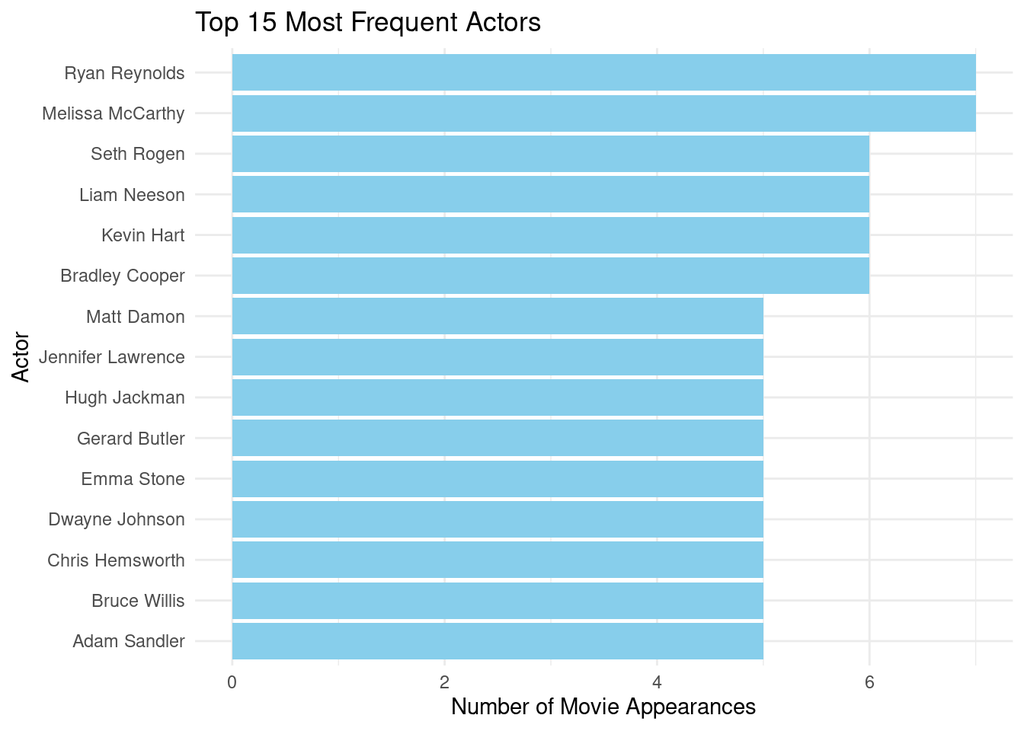

```r
actor_appearance <- clean_movie_data %>%
  select(starts_with("Cast")) %>%
  pivot_longer(cols = everything(), names_to = "Cast_Role", values_to = "Actor") %>%
  filter(!is.na(Actor)) %>%
  group_by(Actor) %>%
  summarise(Appearances = n(), .groups = "drop") %>%
  arrange(desc(Appearances)) %>%
  slice_head(n = 15)

# Plot top 15 actors by appearances
ggplot(actor_appearance, aes(x = fct_reorder(Actor, Appearances), y = Appearances)) +
  geom_col(fill = "skyblue") +
  coord_flip() +
  labs(
    title = "Top 15 Most Frequent Actors",
    x = "Actor",
    y = "Number of Movie Appearances"
  ) +
  theme_minimal()
```

## Average Revenue by Actor:

Which actor brings in the highest box office revenue?

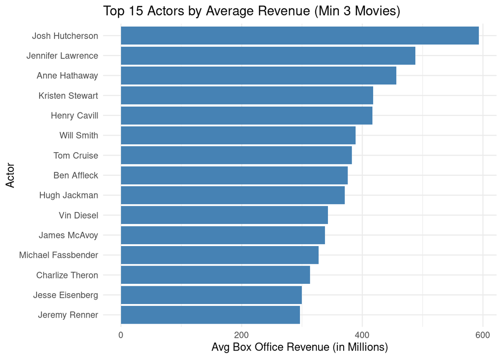

```r
# Merge cast info with revenue
actor_revenue <- clean_movie_data %>%
  select(`Box Office Revenue`, starts_with("Cast")) %>%
  pivot_longer(cols = starts_with("Cast"), names_to = "Cast_Role", values_to = "Actor") %>%
  filter(!is.na(Actor)) %>%
  group_by(Actor) %>%
  summarise(
    Average_Revenue = round(mean(`Box Office Revenue`, na.rm = TRUE) / 1e6, 1),
    Movie_Count = n(),
    .groups = "drop"
  ) %>%
  arrange(desc(Average_Revenue)) %>%
  filter(Movie_Count >= 3) %>%  # Optional: filter to avoid one-movie anomalies
  slice_head(n = 15)

# Plot top actors by average revenue
ggplot(actor_revenue, aes(x = fct_reorder(Actor, Average_Revenue), y = Average_Revenue)) +
  geom_col(fill = "steelblue") +
  coord_flip() +
  labs(
    title = "Top 15 Actors by Average Revenue (Min 3 Movies)",
    x = "Actor",
    y = "Avg Box Office Revenue (in Millions)"
  ) +
  theme_minimal()
```

# 🎬 Director-Genre Specialization

Which genres do specific directors frequently work in?

```r
# Count how many times each director works in each genre
director_genre_freq <- clean_movie_data %>%
  filter(!is.na(Director_1), !is.na(Genre_1)) %>%
  group_by(Director_1, Genre_1) %>%
  summarise(Movie_Count = n(), .groups = "drop") %>%
  arrange(desc(Movie_Count))

# View top combinations
head(director_genre_freq, 10)
```

```
## # A tibble: 10 × 3
##    Director_1            Genre_1 Movie_Count
##    <chr>                 <chr>         <int>
##  1 David Ayer            Action            4
##  2 Nicholas Stoller      Comedy            3
##  3 Shawn Levy            Comedy            3
##  4 Angelina Jolie        Drama             2
##  5 Barry Sonnenfeld      Comedy            2
##  6 Ben Falcone           Comedy            2
##  7 Bryan Singer          Action            2
##  8 Camille Delamarre     Action            2
##  9 Christopher McQuarrie Action            2
## 10 Clint Eastwood        Drama             2
```

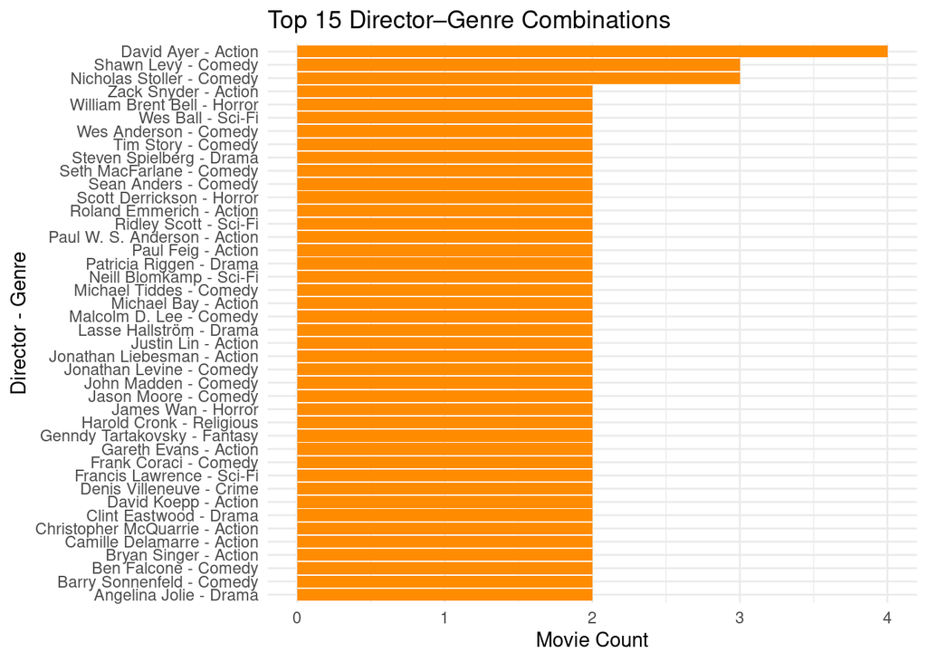

```r
# Optional: visualize top 15 director-genre combos
top_director_genre <- director_genre_freq %>%
  slice_max(order_by = Movie_Count, n = 15)

ggplot(top_director_genre, aes(x = fct_reorder(paste(Director_1, Genre_1, sep = " - "), Movie_Count), y = Movie_Count)) +
  geom_col(fill = "darkorange") +
  coord_flip() +
  labs(
    title = "Top 15 Director–Genre Combinations",
    x = "Director - Genre",
    y = "Movie Count"
  ) +
  theme_minimal()
```

Are certain directors more successful with specific genres?

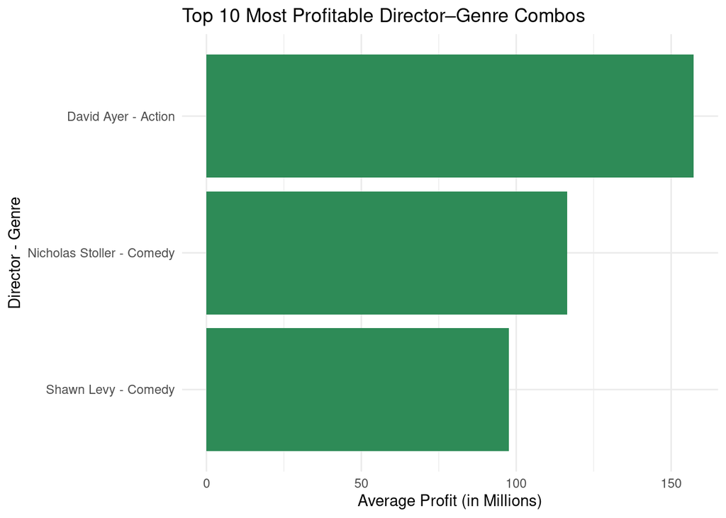

```r
#Compute profit and success metrics by director & genre
director_genre_success <- clean_movie_data %>%
  mutate(
    Profit = `Box Office Revenue` - Budget
  ) %>%
  filter(!is.na(Director_1), !is.na(Genre_1)) %>%
  group_by(Director_1, Genre_1) %>%
  summarise(
    Movies = n(),
    Avg_Revenue = round(mean(`Box Office Revenue`, na.rm = TRUE) / 1e6, 1),
    Avg_Profit = round(mean(Profit, na.rm = TRUE) / 1e6, 1),
    .groups = "drop"
  ) %>%
  filter(Movies >= 3) %>% # optional: only show directors with at least 3 movies in a genre
  arrange(desc(Avg_Profit))

# Top 10 director–genre combos by profit
top_success_director_genre <- director_genre_success %>%
  slice_max(order_by = Avg_Profit, n = 10)

ggplot(top_success_director_genre, aes(x = fct_reorder(paste(Director_1, Genre_1, sep = " - "), Avg_Profit), y = Avg_Profit)) +
  geom_col(fill = "seagreen") +
  coord_flip() +
  labs(
    title = "Top 10 Most Profitable Director–Genre Combos",
    x = "Director - Genre",
    y = "Average Profit (in Millions)"
  ) +
  theme_minimal()
```

# 💸 Profitability Analysis

ROI (Return on Investment) per movie = (Revenue - Budget)/Budget

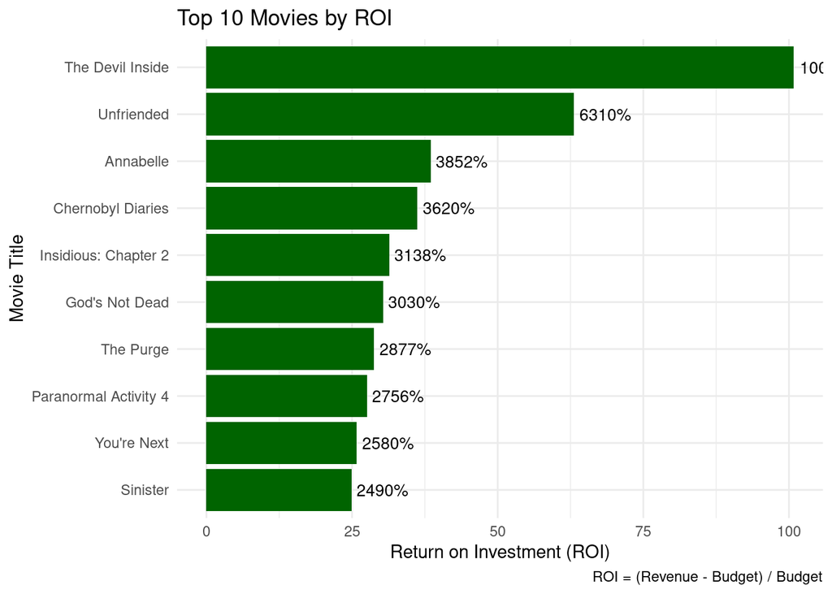

```r
roi_data <- clean_movie_data %>%
  mutate(
    ROI = (`Box Office Revenue` - Budget) / Budget
  ) %>%
  filter(!is.na(ROI), Budget > 0, ROI != Inf) %>%
  arrange(desc(ROI)) %>%
  slice_head(n = 10)  # Top 10 ROI

# Plot top ROI movies
ggplot(roi_data, aes(x = fct_reorder(`Movie Title`, ROI), y = ROI)) +
  geom_col(fill = "darkgreen") +
  geom_text(aes(label = paste0(round(ROI * 100, 0), "%")), hjust = -0.1, size = 3.5) +
  labs(
    title = "Top 10 Movies by ROI",
    x = "Movie Title",
    y = "Return on Investment (ROI)",
    caption = "ROI = (Revenue - Budget) / Budget"
  ) +
  coord_flip() +
  theme_minimal()
```

# 🧑‍🤝‍🧑 Team Effectiveness

## Director–Actor Combos:

Which director-actor pairs consistently generate success?

```r
director_actor_profit <- clean_movie_data %>%
  select(`Movie Title`, Director_1, starts_with("Cast"), Budget, `Box Office Revenue`) %>%
  mutate(Profit = `Box Office Revenue` - Budget) %>%
  pivot_longer(cols = starts_with("Cast"), names_to = "Cast_Role", values_to = "Actor") %>%
  filter(!is.na(Director_1), !is.na(Actor)) %>%
  group_by(Director_1, Actor) %>%
  summarise(
    Movie_Count = n(),
    Avg_Profit = round(mean(Profit, na.rm = TRUE) / 1e6, 1),
    Success_Rate = mean(Profit > 0),
    .groups = "drop"
  ) %>%
  filter(Movie_Count >= 2)  # Only consider recurring pairs

top_avg_profit_pairs <- director_actor_profit %>%
  arrange(desc(Avg_Profit)) %>%
  slice_head(n = 5)

ggplot(top_avg_profit_pairs, aes(x = fct_reorder(paste(Director_1, Actor, sep = " & "), Avg_Profit), y = Avg_Profit)) +
  geom_col(fill = "purple") +
  geom_text(aes(label = paste0(Avg_Profit, "M")), hjust = -0.1, size = 3.5) +
  labs(
    title = "Top 5 Director–Actor Pairs by Average Profit",
    x = "Director & Actor",
    y = "Avg Profit (in Millions)"
  ) +
  coord_flip() +
  theme_minimal()
```

[figure not shown]

Top 5 collaborative pairs by average profit or success rate.

```r
# Combine all cast columns into one long format
actor_appearance <- clean_movie_data %>%
  select(starts_with("Cast")) %>%
  pivot_longer(cols = everything(), names_to = "Cast_Role", values_to = "Actor") %>%
  filter(!is.na(Actor)) %>%
  group_by(Actor) %>%
  summarise(Appearances = n(), .groups = "drop") %>%
  arrange(desc(Appearances)) %>%
  slice_head(n = 15)
```

# 🎭 Multi-genre Movies

Compare single-genre vs. dual-genre movies in terms of:

Average budget

Average revenue

Success rate

```r
# Label movies based on genre columns
genre_comparison <-movie_data %>%
  mutate(
    Genre_Type = if_else(!is.na(Genre_2), "Multi-genre", "Single-genre"),
    Profit = `Box Office Revenue` - Budget,
    Success = Profit > 0
  ) %>%
  group_by(Genre_Type) %>%
  summarise(
    Avg_Budget = round(mean(Budget, na.rm = TRUE) / 1e6, 1),
    Avg_Revenue = round(mean(`Box Office Revenue`, na.rm = TRUE) / 1e6, 1),
    Success_Rate = round(mean(Success, na.rm = TRUE) * 100, 1),
    Movie_Count = n(),
    .groups = "drop"
  )

print(genre_comparison)
```

```
## # A tibble: 2 × 5
##   Genre_Type   Avg_Budget Avg_Revenue Success_Rate Movie_Count
##   <chr>             <dbl>       <dbl>        <dbl>       <int>
## 1 Multi-genre        55.7        162.         83.6         262
## 2 Single-genre       41.6        142.         79.7         246
```

# 📈 Genre Revenue Efficiency

Revenue-to-budget ratio per genre.

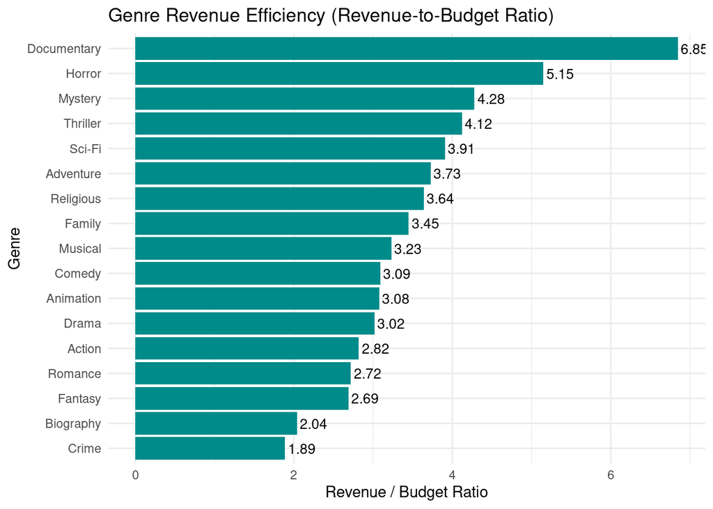

```r
genre_efficiency <- clean_movie_data %>%
  filter(!is.na(Genre_1)) %>%
  group_by(Genre_1) %>%
  summarise(
    Total_Revenue = sum(`Box Office Revenue`, na.rm = TRUE),
    Total_Budget = sum(Budget, na.rm = TRUE),
    Efficiency = round(Total_Revenue / Total_Budget, 2),
    .groups = "drop"
  ) %>%
  filter(Total_Budget > 0) %>%
  arrange(desc(Efficiency))

ggplot(genre_efficiency, aes(x = fct_reorder(Genre_1, Efficiency), y = Efficiency)) +
  geom_col(fill = "darkcyan") +
  geom_text(aes(label = Efficiency), hjust = -0.1, size = 3.5) +
  labs(
    title = "Genre Revenue Efficiency (Revenue-to-Budget Ratio)",
    x = "Genre",
    y = "Revenue / Budget Ratio"
  ) +
  coord_flip() +
  theme_minimal()
```

This tells you which genres are most efficient in generating profit.

# 📆 Release Timing Impact

Analyze by month to see if release timing impacts box office success.

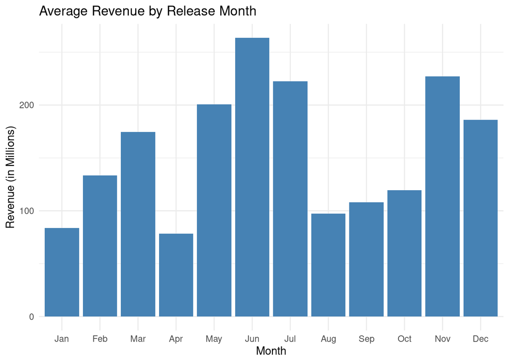

```r
release_timing <- clean_movie_data %>%
  mutate(
    Release_Date = mdy_hm(`Release Date`),
    Release_Month = month(Release_Date, label = TRUE, abbr = TRUE),  # e.g., Jan, Feb
    Release_Quarter = quarter(Release_Date, with_year = FALSE),
    Profit = `Box Office Revenue` - Budget,
    Success = Profit > 0
  )

by_month <- release_timing %>%
  group_by(Release_Month) %>%
  summarise(
    Avg_Revenue = round(mean(`Box Office Revenue`, na.rm = TRUE) / 1e6, 1),
    Avg_Profit = round(mean(Profit, na.rm = TRUE) / 1e6, 1),
    Success_Rate = round(mean(Success, na.rm = TRUE) * 100, 1),
    Movie_Count = n(),
    .groups = "drop"
  )

# Revenue
ggplot(by_month, aes(x = Release_Month, y = Avg_Revenue)) +
  geom_col(fill = "steelblue") +
  labs(title = "Average Revenue by Release Month", y = "Revenue (in Millions)", x = "Month") +
  theme_minimal()
```

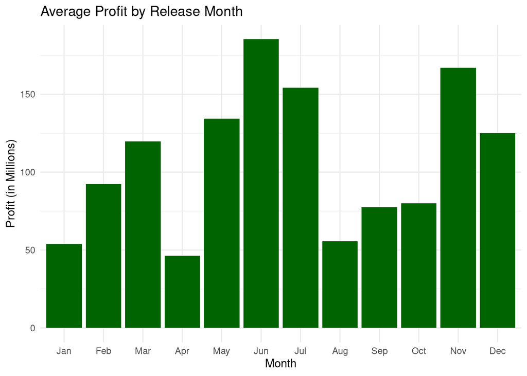

```r
# Profit
ggplot(by_month, aes(x = Release_Month, y = Avg_Profit)) +
  geom_col(fill = "darkgreen") +
  labs(title = "Average Profit by Release Month", y = "Profit (in Millions)", x = "Month") +
  theme_minimal()
```